# DrugUtilisation - Práctica

Creación y caracterización de drug utilisation cohorts

Author

Affiliation

Marti Catala Sabate

University of Oxford

## Conectarse a la base de datos

Para esta práctica vamos a usar Synthetic data **synthea-covid19-10k**, una base de datos sintética de 10,754 personas mapeada a OMOP CDM. Para crear la conexión podéis usar las siguientes líneas de código:

```r
dbName <- "synthea-covid19-10k"
CDMConnector::requireEunomia(datasetName = dbName)
con <- duckdb::dbConnect(duckdb::duckdb(), CDMConnector::eunomiaDir(datasetName = dbName))
cdm <- CDMConnector::cdmFromCon(con = con, cdmSchema = "main", writeSchema = "main")
cdm
```

```
── # OMOP CDM reference (duckdb) of Synthea ────────────────────────────────────
```

```
• omop tables: attribute_definition, care_site, cdm_source, cohort_definition,
concept, concept_ancestor, concept_class, concept_relationship,
concept_synonym, condition_era, condition_occurrence, cost, death,
device_exposure, domain, dose_era, drug_era, drug_exposure, drug_strength,
fact_relationship, location, measurement, metadata, note, note_nlp,
observation, observation_period, payer_plan_period, person,
procedure_occurrence, provider, relationship, source_to_concept_map, specimen,
visit_detail, visit_occurrence, vocabulary
```

```
• cohort tables: -
```

```
• achilles tables: -
```

```
• other tables: -
```

## 1 Diagnostics

### Crear una ‘codelist’ de ‘clopidogrel’

```
- 32968_clopidogrel (2809 codes)
```

**Pista**

Puedes usar la función `CodelistGenerator::getDrugIngredientCodes()`

### DrugExposureDiagnostics

Una vez creada la codelist podemos usar el paquete DrugExposureDiagnostics para analizar la calidad de los records de esta codelist en la base de datos.

Pasos:

**1) Tendremos que buscar el ingredient concept id de clopidogrel.**

**Pista 1**

La tabla ‘concept’ (`cdm$concept`) tiene la relación entre concept_id y concept_name. También se puede buscar esta relación en athena.

**Pista 2**

Puedes filtrar la tabla usando `dplyr::filter()` por ejemplo:

```r
cdm$concept |>
  dplyr::filter(concept_name == "my_ingredient")
```

**2) Usar DrugExposureDiagnostics para obtener el diagnóstico de esta codelist:**

**Pista**

Recuerda que la función para hacer diagnostics es: *DrugExposureDiagnostics::executeChecks*.

Recuerda usar los argumentos:

- ingredients
- earliestStartDate (recuerda que por defecto es ‘2010-01-01’)
- sample (recuerda que por defecto es 10,000)
- outputFolder (para que los resultados se guarden en un zip)

NOTE: en una base de datos completa *DrugExposureDiagnostics* puede tardar horas en obtener los resultados.

**3) Crear la shiny app con los resultados de DrugExposureDiagnostics**

**Pista**

Recuerda que la función para crear la shiny es: *DrugExposureDiagnostics::viewResults*.

Tienes que usar el mismo ‘dataFolder’ donde hay los resultados en .zip

Tendrías que ver una shiny app parecida a esta:

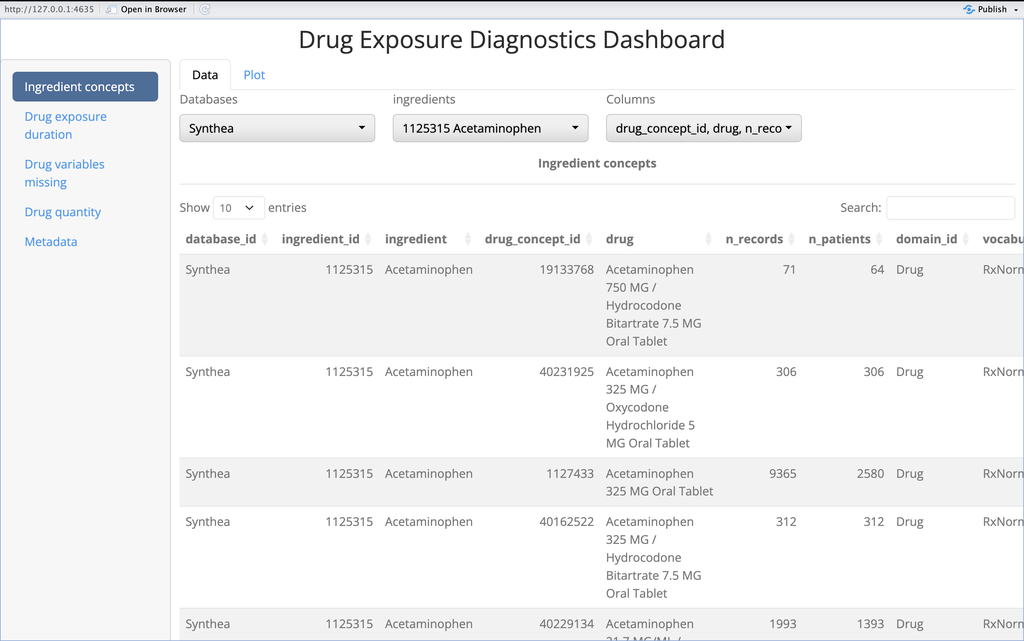

**4) Explora la shiny app y responde a las siguientes preguntas:**

**Q1)** ¿Cuántos concept ids tienen records asociados?

**Pista**

Puedes encontrar las respuestas en la tab con titulo: ‘Ingredient concepts’

**Resultado**

Solo un concepto tiene records: 19075601 (N = 4,179).

**Q2)** ¿Hay alguna duración negativa? ¿La longitud de los exposure parece plausible?

**Pista**

Puedes encontrar las respuestas en la tab con titulo: ‘Drug exposure duration’

**Resultado**

No hay duraciones negativas. La longitud de los exposures parece plausible.

**Q3)** ¿Hay algún missing del que nos tengamos que preocupar?

**Pista**

Puedes encontrar las respuestas en la tab con titulo: ‘Drug variables missing’.

Ten en cuenta que las columnas mas importantes son: drug_concept_id, person_id, drug_exposure_start_date, drug_exposure_end_date and quantity.

**Resultado**

Hay algunos missings, pero ninguna de las columnas que tienen missings son de vital importancia para nuestros análisis.

**Q4)** ¿Qué te parecen los valores de quantity? ¿Va a ser posible calcular dose?

**Pista**

Puedes encontrar las respuestas en la tab con titulo: ‘Drug quantity’.

**Resultado**

Quantity es 0 siempre así que no se podrá calcular dose.

## 2 Analyses

### Crear una cohorte

Ahora que tenemos nuestro ‘codelist’ podemos crear una cohorte de usuarios de ‘clopidogrel’, crea la cohorte considerando que prescripciones separadas por 30 días siguen formando parte del mismo episodio de uso del medicamento. Comprueba el ‘cohortCount’ y compara tu resultado con el esperado.

**Q5)** ¿Cuántos records y subjects tiene la cohorte resultante?

**Pista**

Recuerda que puedes usar la función `DrugUtilisation::generateDrugUtilisationCohortSet()` para crear cohortes de usuarios de fármacos. Con el parámetro `gapEra` indicamos cuántos días de separación puede haber entre dos exposures para ser considerados dentro del mismo episodio.

**Resultado**

```
# A tibble: 1 × 3
  cohort_definition_id number_records number_subjects
                 <int>          <int>           <int>
1                    1           1783            1530
```

### Nuevos usuarios

En este estudio vamos a considerar que nuevos usuarios de ‘clopidogrel’ son aquellos que:

- No han usado ‘clopidogrel’ en los 365 dias anteriores.
- Han estado en observacion durante los 365 dias anteriores.
- Periodo de estudio: 1990-01-01 to any time after.

**Q6)** ¿Cuántos records y subjects tiene la cohorte resultante? Visualizando la attrition, ¿en qué paso se pierden más personas?

**Pista**

Uso del mismo medicamento anteriormente -> `DrugUtilisation::requirePriorDrugWashout()`

En observacion antes del medicamento -> `DrugUtilisation::requireObservationBeforeDrug()`

Periodo de estudio -> `DrugUtilisation::requireDrugInDateRange()`

**Resultado**

```
# A tibble: 1 × 3
  cohort_definition_id number_records number_subjects
                 <int>          <int>           <int>
1                    1           1207            1165
```

```
# A tibble: 5 × 2
  reason                                        number_records
  <chr>                                                  <int>
1 Initial qualifying events                               1801
2 Collapse records separated by 30 or less days           1783
3 require prior use days of 365 days                      1597
4 require prior observation of 365 days                   1207
5 require cohort_start_date after 1990-01-01              1207
```

### Caracterizacion

Vamos a caracterizar el uso de ‘clopidogrel’ en nuestra cohorte de ‘clopidogrel’, vamos a usar un gapEra de 30 días tal y como lo hemos hecho a la creación de la cohorte. Vamos a caracterizar las prescripciones durante la cohorte y visualizarlo en una ‘gt table’.

NOTA: Recuerda que en el diagnostics hemos visto que para este fármaco no podemos analizar quantity o dose, así que vamos a poner estas opciones en FALSE.

**Q7)** ¿Cuáles de los resultados son esperados? ¿Hay algún resultado sorprendente?

**Pista**

Extraer uso de los medicamentos: `DrugUtilisation::summariseDrugUtilisation()`

Visualizarlo en un ‘gt table’: `DrugUtilisation::tableDrugUtilisation()`

**Resultado**

| Variable name | Estimate name | CDM name Synthea |
| --- | --- | --- |
| 32968_clopidogrel |  |  |
| number records | N | 1,207 |
| number subjects | N | 1,165 |
| number exposures | Median (Q25 - Q75) | 2 (1 - 3) |
| time to exposure | Median (Q25 - Q75) | 0 (0 - 0) |
| initial exposure duration | Median (Q25 - Q75) | 1 (1 - 390) |
| number eras | Median (Q25 - Q75) | 1 (1 - 1) |
| days exposed | Median (Q25 - Q75) | 1 (1 - 400) |
| days prescribed | Median (Q25 - Q75) | 2 (1 - 742) |

### Indicacion

Encuentra cuales son las posibles indicaciones de los usuarios de ‘clopidogrel’. Considera como posibles indicaciones: “Coronary arteriosclerosis” (317576) y “Cerebrovascular accident” (381316), ademas busca cuanta gente tiene algun otro record (“Unknown indication”) en “condition_occurrence”. Busca indications en: [-365, 0] y [0, 0] respecto el index date. Visualiza el resultado en una ‘gt’ table.

**Q8)** ¿Cambia mucho el resultado por usar distintas ventanas?

**Q9)** Cuando el resultado de ‘unknown’ es un porcentaje significativo seguramente haríamos una large scale characterisation para ver qué records están presentes, ¿crees que hace falta en este caso?

**Crear indications cohort**

**Pista**

Puedes analizar la indicación con la función `DrugUtilisation::summariseIndication()` y después visualizarla con `DrugUtilisation::tableIndication()`.

**Resultado**

| Indication | Estimate name | CDM name Synthea Cohort name 32968_clopidogrel |
| --- | --- | --- |
| Indication from 365 days before to the index date |  |  |
| cerebrovascular_accident | N (%) | 304 (25.19 %) |
| coronary_arteriosclerosis | N (%) | 554 (45.90 %) |
| cerebrovascular_accident and coronary_arteriosclerosis | N (%) | 0 (0.00 %) |
| unknown | N (%) | 29 (2.40 %) |
| none | N (%) | 320 (26.51 %) |
| not in observation | N (%) | 0 (0.00 %) |
| Indication on index date |  |  |
| cerebrovascular_accident | N (%) | 300 (24.86 %) |
| coronary_arteriosclerosis | N (%) | 554 (45.90 %) |
| cerebrovascular_accident and coronary_arteriosclerosis | N (%) | 0 (0.00 %) |
| unknown | N (%) | 22 (1.82 %) |
| none | N (%) | 331 (27.42 %) |
| not in observation | N (%) | 0 (0.00 %) |

### Comedications

Vamos a analizar las medicaciones que se toman simultáneamente a ‘clopidogrel’, los candidatos van a ser 3 otros ingredientes: ‘warfarin’, ‘enoxaparin’ y ‘alteplase’.

Pasos:

- Crear la codelist de medicaciones alternativas
- Crear la cohorte de medicaciones alternativas
- Usar la función `DrugUtilisation::summariseTreatment()` para ver los tratamientos simultáneos, ¿qué valor hay que poner en ‘indexDate’, ‘censorDate’ y ‘window’?
- Visualiza los resultados con la función `DrugUtilisation::plotTreatment()`.

**Q10)** ¿Cuál es la comedicación más común?

**Resultado**

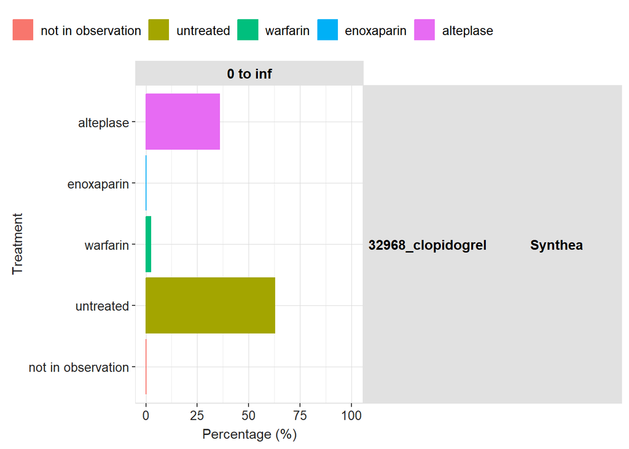

### Medications antes y después

Vamos a analizar qué medicamentos de estos 3 se han usado antes o después de empezar el tratamiento. Vamos a usar la misma función que antes pero en vez de analizar el durante vamos a analizar el antes y el después, definimos 5 ventanas: [-360, -181], [-180, -1], [0, 0], [1, 180] y [181, 360] y vamos a ver qué tratamientos se usaron.

**Q11)** ¿Hay algún medicamento que se tome antes o después del ‘clopidogrel’?

**Resultado**

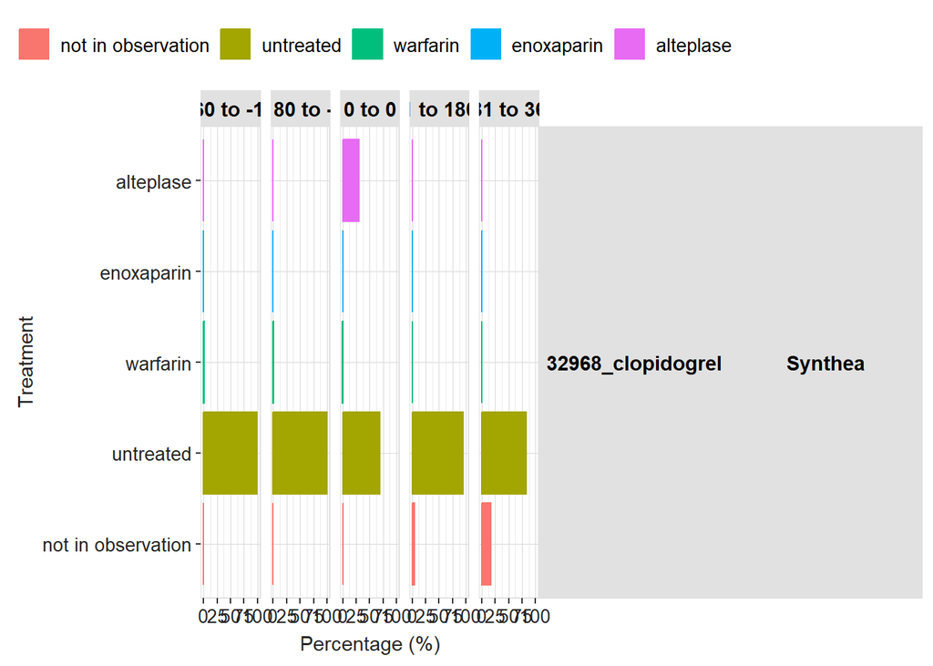

### Discontinuation

Para analizar cuánto tardan los pacientes en dejar la medicación podemos usar ‘proportion of patients covered’ durante los 365 días después de iniciar el tratamiento.

**Q12)** ¿Qué vemos? ¿Hay algún momento en que muchos pacientes dejen la medicación al mismo tiempo?

**Pista**

Puedes analizar PPC con la función `DrugUtilisation::summariseProportionOfPatientsCovered()` y después visualizarlo con `DrugUtilisation::plotProportionOfPatientsCovered()`.

**Resultado**

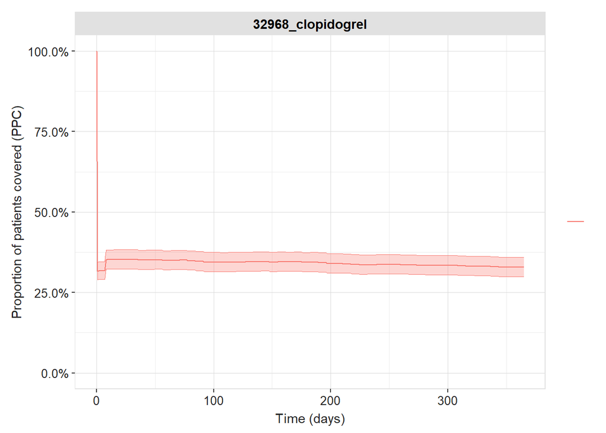

### Drug restart and switch

Vamos a usar las mismas cohortes que hemos usado antes (‘warfarin’, ‘enoxaparin’ y ‘alteplase’) para ver si después de terminar el tratamiento de ‘clopidogrel’ los usuarios cambian a alguna de ellas o vuelven a empezar el tratamiento.

**Resultado**

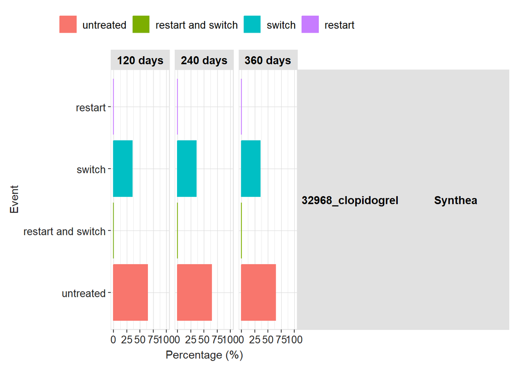